# COVID19 Basic Time Series Analysis

## COVID19 Basic Time Series Analysis

This analysis is based on data collected and publish Jonh Hopkins University as of April 3rd 2020. The data can be downloaded from the following github web page.

https://github.com/CSSEGISandData/COVID-19

There have been multiple approaches to hanlding the Coronavirus Crisis around the world. The following analysis shows in a graphical manner the outcomes by country/region over the last several weeks. It provides evidence of what type of approach is more effective and what are the actions that individuals, communities and government should take to control the spread of the virus.

The first section compares regions around the world and how they first addressed the first days of the pandemic. China will be treated as its own region. Selected countries, with good data quality, will be used as reference.

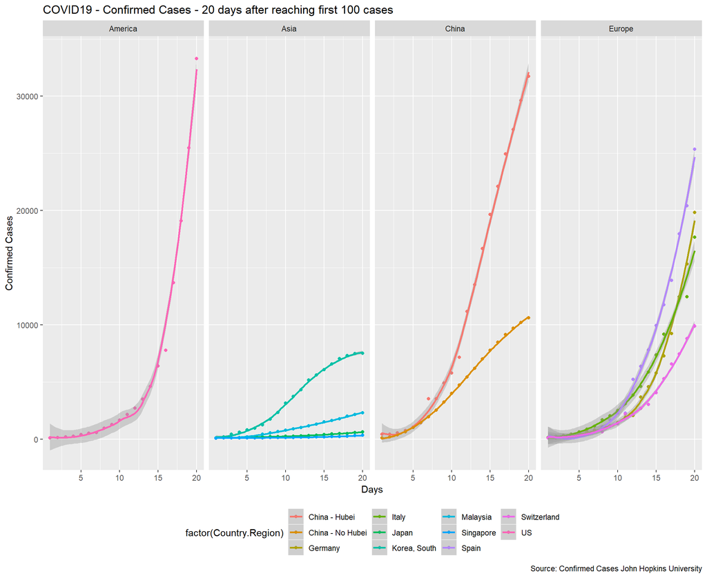

```r
#Load John Hopkins University Data - From Local copy. Same information available in Github website
Confirmed = read.csv("C:/Users/figue/OneDrive/Documents/GitHub/COVID-19/csse_covid_19_data/csse_covid_19_time_series/time_series_covid19_confirmed_global.csv",stringsAsFactors = FALSE)
Deaths= read.csv("C:/Users/figue/OneDrive/Documents/GitHub/COVID-19/csse_covid_19_data/csse_covid_19_time_series/time_series_covid19_deaths_global.csv",stringsAsFactors = FALSE)

#Prepare Data. Will focus on confirmed cases.
#China will be divided in Hubei and Not Hubei.
#For Asia use South Korea, Japan, Singapore, Malaysia
# For Europe Italy, Spain, Switzerland and Germany

#Limit data to Select Countries
Countries = c("China", "Korea, South", "Japan", "Malaysia", "Singapore", "Italy", "Spain", "Switzerland", "Germany","US")

Confirmed.Selected = Confirmed[Confirmed$Country.Region %in% Countries,]
Deaths.Selected = Deaths[Deaths$Country.Region %in% Countries,]

#Update information for China Hubei and No Hubei
#
Confirmed.Selected$Province.State = ifelse(Confirmed.Selected$Country.Region=="China" & Confirmed.Selected$Province.State!="Hubei","No Hubei","" )
Deaths.Selected$Province.State = ifelse(Deaths.Selected$Country.Region=="China" & Deaths.Selected$Province.State!="Hubei","No Hubei","" )

library(dplyr)
#summarize information by country. In particular China.

Ncol = dim(Confirmed.Selected)[2]
Confirmed.Selected.Sum = Confirmed.Selected[,c(1,2,5:Ncol)] %>% group_by(Province.State,Country.Region) %>% summarise_at(colnames(Confirmed.Selected)[5:Ncol],sum)

Ncol = dim(Deaths.Selected)[2]
Deaths.Selected.Sum = Deaths.Selected[,c(1,2,5:Ncol)] %>% group_by(Province.State,Country.Region) %>% summarise_at(colnames(Deaths.Selected)[5:Ncol],sum)

#Now Update China Country.Region values to China Hubei and China No Hubei

Confirmed.Selected.Sum[Confirmed.Selected.Sum$Country.Region=="China","Country.Region"] = ifelse(Confirmed.Selected.Sum[Confirmed.Selected.Sum$Country.Region=="China","Province.State"] == "No Hubei","China - No Hubei", "China - Hubei")

Deaths.Selected.Sum[Deaths.Selected.Sum$Country.Region=="China","Country.Region"] = ifelse(Deaths.Selected.Sum[Deaths.Selected.Sum$Country.Region=="China","Province.State"] == "No Hubei","China - No Hubei", "China - Hubei")

#For Only Confirm find the first date / column where more than 100 cases is found

#this provides the matrix of values of 100 or more. Remember that column 1 is equivalent to column 5
temp.matrix = which(Confirmed.Selected.Sum[,3:dim(Confirmed.Selected.Sum)[2]]>=100, arr.ind=TRUE)
#I would  agregate by row  using the minimum column

# there are many for which the cross of 100 cases is very recent
temp.matrix = aggregate(col ~ row, data= temp.matrix, min)


# add 2 to the column. to skip first two columns which contain Province.State and Country.Region
temp.matrix[,"col"]= temp.matrix[,"col"] + 2

#Add Starting Column for first 100 cases
Confirmed.Selected.Sum$Col_Cases_100 = temp.matrix[,"col"]

#Add 20 fields to keep track of 20 days after first 100 cases
Confirmed.Selected.Sum[c("D_01","D_02","D_03","D_04","D_05","D_06","D_07","D_08","D_09","D_10","D_11","D_12","D_13","D_14","D_15","D_16","D_17","D_18","D_19","D_20")] = 0

#Conver to Dataframe

Confirmed.Selected.Sum = as.data.frame(Confirmed.Selected.Sum)

#Number of rows
N = dim(Confirmed.Selected.Sum)[1]

#have to populate D_1 to D_20 for each location
for(i in 1:N){
  Confirmed.Selected.Sum[i,c("D_01","D_02","D_03","D_04","D_05","D_06","D_07","D_08","D_09","D_10","D_11","D_12","D_13","D_14","D_15","D_16","D_17","D_18","D_19","D_20")]=Confirmed.Selected.Sum[i,c(Confirmed.Selected.Sum[i,"Col_Cases_100"]:(Confirmed.Selected.Sum[i,"Col_Cases_100"]+19))]
}

#Confirmed.Selected.Sum Add Continent.Region

Confirmed.Selected.Sum$Continent.Region = NA

Confirmed.Selected.Sum[Confirmed.Selected.Sum$Country.Region %in% c("Korea, South", "Japan", "Malaysia", "Singapore"),"Continent.Region"]="Asia"
Confirmed.Selected.Sum[Confirmed.Selected.Sum$Country.Region %in% c("Italy", "Spain", "Switzerland", "Germany"),"Continent.Region"]="Europe"
Confirmed.Selected.Sum[Confirmed.Selected.Sum$Country.Region =="US","Continent.Region"]="America"
Confirmed.Selected.Sum[grep("China", Confirmed.Selected.Sum$Country.Region),"Continent.Region"]="China"

library(reshape2)

Confirmed.Selected.Sum.long = reshape(Confirmed.Selected.Sum[,c("Country.Region","Continent.Region","D_01","D_02","D_03","D_04","D_05","D_06","D_07","D_08","D_09","D_10","D_11","D_12","D_13","D_14","D_15","D_16","D_17","D_18","D_19","D_20")],varying=c("D_01","D_02","D_03","D_04","D_05","D_06","D_07","D_08","D_09","D_10","D_11","D_12","D_13","D_14","D_15","D_16","D_17","D_18","D_19","D_20"),v.names="Confirmed",idvar=c("Country.Region","Continent.Region"),direction="long")

library(ggplot2)
#loess method
#without Other

ggplot(Confirmed.Selected.Sum.long, aes(x= time, y= Confirmed, group=Country.Region )) +   geom_point(aes(color = factor(Country.Region))) + geom_smooth(method = "loess",aes(color = factor(Country.Region))) + theme(legend.position="bottom") + labs(title="COVID19 - Confirmed Cases - 20 days after reaching first 100 cases", y="Confirmed Cases", x="Days", caption="Source: Confirmed Cases John Hopkins University") +  facet_grid(. ~ Continent.Region)
```

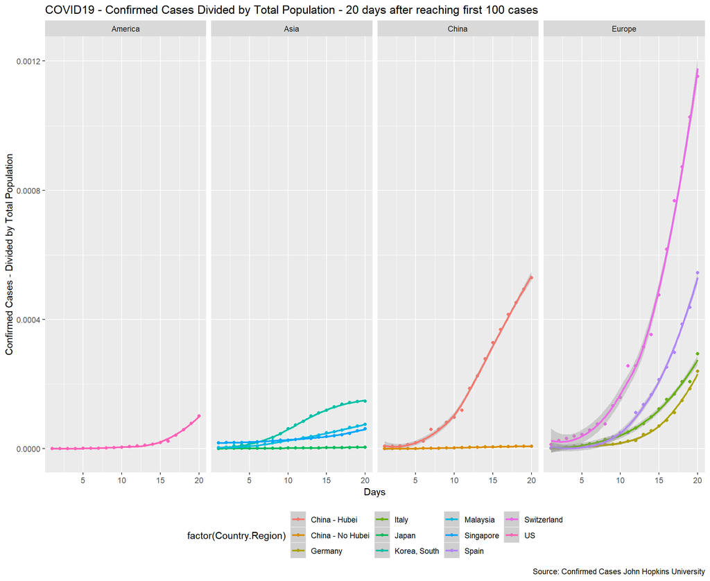

```r
#After Normalizing by Total Population

Population.Country = data.frame(Region=c("China - Hubei", "China - No Hubei", "Korea, South", "Japan", "Malaysia", "Singapore", "Italy", "Spain", "Switzerland", "Germany","US"),Population=c(60000000, 1326000000, 51000000, 126000000, 31000000, 5600000, 60000000,46600000, 8570000, 82700000, 327000000))

#Add Population

Confirmed.Selected.Sum = merge(Confirmed.Selected.Sum,Population.Country,by.x="Country.Region",by.y="Region",all.x=TRUE, all.y=FALSE)
#create new columns to calculate confirmed cases by % of population
#First Assign same values by days
Confirmed.Selected.Sum[c("D_01P","D_02P","D_03P","D_04P","D_05P","D_06P","D_07P","D_08P","D_09P","D_10P","D_11P","D_12P","D_13P","D_14P","D_15P","D_16P","D_17P","D_18P","D_19P","D_20P")] = Confirmed.Selected.Sum[c("D_01","D_02","D_03","D_04","D_05","D_06","D_07","D_08","D_09","D_10","D_11","D_12","D_13","D_14","D_15","D_16","D_17","D_18","D_19","D_20")]

#Then divide by population

Confirmed.Selected.Sum[c("D_01P","D_02P","D_03P","D_04P","D_05P","D_06P","D_07P","D_08P","D_09P","D_10P","D_11P","D_12P","D_13P","D_14P","D_15P","D_16P","D_17P","D_18P","D_19P","D_20P")] = Confirmed.Selected.Sum[c("D_01P","D_02P","D_03P","D_04P","D_05P","D_06P","D_07P","D_08P","D_09P","D_10P","D_11P","D_12P","D_13P","D_14P","D_15P","D_16P","D_17P","D_18P","D_19P","D_20P")] / Confirmed.Selected.Sum$Population


Confirmed.Selected.Sum.long.p = reshape(Confirmed.Selected.Sum[,c("Country.Region","Continent.Region","D_01P","D_02P","D_03P","D_04P","D_05P","D_06P","D_07P","D_08P","D_09P","D_10P","D_11P","D_12P","D_13P","D_14P","D_15P","D_16P","D_17P","D_18P","D_19P","D_20P")],varying=c("D_01P","D_02P","D_03P","D_04P","D_05P","D_06P","D_07P","D_08P","D_09P","D_10P","D_11P","D_12P","D_13P","D_14P","D_15P","D_16P","D_17P","D_18P","D_19P","D_20P"),v.names="Confirmed",idvar=c("Country.Region","Continent.Region"),direction="long")


ggplot(Confirmed.Selected.Sum.long.p, aes(x= time, y= Confirmed, group=Country.Region )) +   geom_point(aes(color = factor(Country.Region))) + geom_smooth(method = "loess",aes(color = factor(Country.Region))) + theme(legend.position="bottom") + labs(title="COVID19 - Confirmed Cases Divided by Total Population - 20 days after reaching first 100 cases", y="Confirmed Cases - Divided by Total Population", x="Days", caption="Source: Confirmed Cases John Hopkins University") +  facet_grid(. ~ Continent.Region)
```

By proportion of confirmed cases to population , the US looks to be doing a good job at containing the cases in the first 20 days after reaching 100 cases. In terms of cases it is increasing rapidly. For China, the Hubei province would be a good case for study for controlling the Spread. According to the Data , all other provinces in China did not have heavy community spread of the virus. For Asia, South Korea had a good success in containing the spread of the virus. In the first 20 days, it does not look like any country in Europe took actions fast enough.

In the next section we will review the mortality rate by country. The rate by confirmed case is documented by John Hopkins Universtiy in the following web site:

https://coronavirus.jhu.edu/data/mortality

There is great variability, most likely because there is great variability in testing. I will review the cases for several countries to find parameters that allow to calculate the most likely number of infections based on number of deaths.

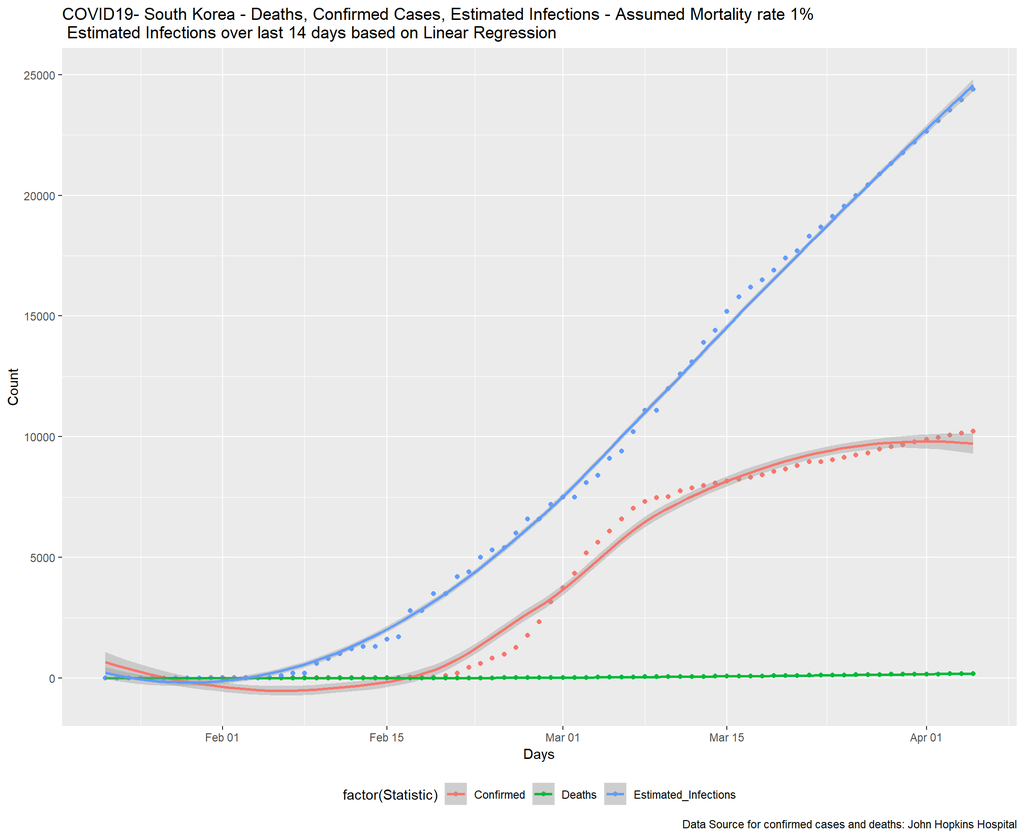

```r
#Create a function that takes the Dataframe for Confirmed Cases and Deaths
#in the Timeseries format provided by John Hopkins in the Global format
#Returns a Dataframe to use in Ggplot that

Estimated.Infections.Country <- function(Confirm, Death , Country.Terr, State=NA, Lag=14 , Mortality=0.01){
  # Have to add checks in the future. Currently it works with Exact Matches
  library(reshape2)

  if (is.na(State)){
    Country.Confirmed = Confirm[Confirm$Country.Region == Country.Terr,]
    Country.Deaths = Death[Death$Country.Region == Country.Terr,]
  }else {
    Country.Confirmed = Confirm[Confirm$Country.Region == Country.Terr & Confirm$Province.State == State,]
    Country.Deaths = Death[Death$Country.Region == Country.Terr & Death$Province.State == State,]
  }

  #confirmed transform into long format
  Country.Confirmed$Statistic = "Confirmed"

  Country.Confirmed.Long = reshape(Country.Confirmed,varying = colnames(Country.Confirmed[,5:(dim(Country.Confirmed)[2]-1)]),v.names="Confirmed",idvar=c("Province.State","Country.Region","Lat","Long","Statistic"),direction="long")
  #Add corresponding date to Count
  Country.Confirmed.Long$Date_Name = colnames(Country.Confirmed[,5:(dim(Country.Confirmed)[2]-1)])

  #create Dataframe for Deaths. Transform into long format



  Country.Deaths$Statistic = "Deaths"
  Country.Deaths.Long = reshape(Country.Deaths,varying = colnames(Country.Deaths[,5:(dim(Country.Deaths)[2]-1)]),v.names="Deaths",idvar=c("Province.State","Country.Region","Lat","Long","Statistic"),direction="long")

  #Add corresponding date to Count
  Country.Deaths.Long$Date_Name = colnames(Country.Deaths[,5:(dim(Country.Deaths)[2]-1)])
  Country.Deaths.Long$Estimated_Infections = NA
  #Deaths is a 14 lag to infections. 1% Mortality rate. Have to start from row 15
  ##Maximum Lag will be 14
  if (Lag >15 ) Lag=14
  #Have to add limits to morality rate >0 and <=1
  Country.Deaths.Long[c(1:(dim(Country.Deaths.Long)[1]-Lag)),"Estimated_Infections"] = Country.Deaths.Long[c((Lag+1):dim(Country.Deaths.Long)[1]),"Deaths"]*(1/Mortality)

  #merge deaths and confirmed

  Country = merge(Country.Confirmed.Long,Country.Deaths.Long[,c("Date_Name","Deaths","Estimated_Infections")],by="Date_Name")
  Country = Country[order(Country$time),]

  #add dates in right format. Convert Date_Name

  Country$Date = as.Date(substr(Country$Date_Name,2,nchar(Country$Date_Name)),format ="%m.%d.%y")
  #change  for ggplot

  Country.Long = melt(Country[c("Date","Confirmed","Deaths","Estimated_Infections")],id="Date")
  #update names
  colnames(Country.Long) = c("Date","Statistic","Count")
  #calculate linear regression with last 5 values of Estimated infections
  Est.Infect.reduced = Country.Long[Country.Long$Statistic=="Estimated_Infections",c("Date","Count")]
  #only 5 values prior to NA
  temp = min(which(is.na(Est.Infect.reduced$Count)))

  lm.infect = lm(Count ~ Date, data=Est.Infect.reduced[c((temp-5):(temp-1)),])
  #predict for missing dates and append to Es.Infect.reduced

  #predict based on 5 last records and add to NAs as probable number of  infections. Directly to

  #predict(lm.infect,newdata=data.frame(Date=Est.Infect.reduced[is.na(Est.Infect.reduced$Count),"Date"]))
  #Est.Infect.reduced[is.na(Est.Infect.reduced$Count),"Date"] = predict(lm.infect,newdata=data.frame(Date=Est.Infect.reduced[is.na(Est.Infect.reduced$Count),"Date"]))
  Country.Long[Country.Long$Statistic=="Estimated_Infections" & is.na(Country.Long$Count),"Count"] = predict(lm.infect,newdata=data.frame(Date=Est.Infect.reduced[is.na(Est.Infect.reduced$Count),"Date"]))

  return(Country.Long)

}

#check with


#Example with South Korea and Germany - 1% Mortaliy rate and 14 day lag of Number of Death to Estimated Infections
Country.Long = Estimated.Infections.Country(Confirmed,Deaths,"Korea, South")
ggplot(Country.Long, aes(x= Date, y= Count, group=Statistic )) +   geom_point(aes(color = factor(Statistic))) + geom_smooth(method = "loess", aes(color = factor(Statistic))) + theme(legend.position="bottom") + labs(title="COVID19- South Korea - Deaths, Confirmed Cases, Estimated Infections - Assumed Mortality rate 1% \n Estimated Infections over last 14 days based on Linear Regression", y="Count", x="Days", caption="Data Source for confirmed cases and deaths: John Hopkins Hospital")
```

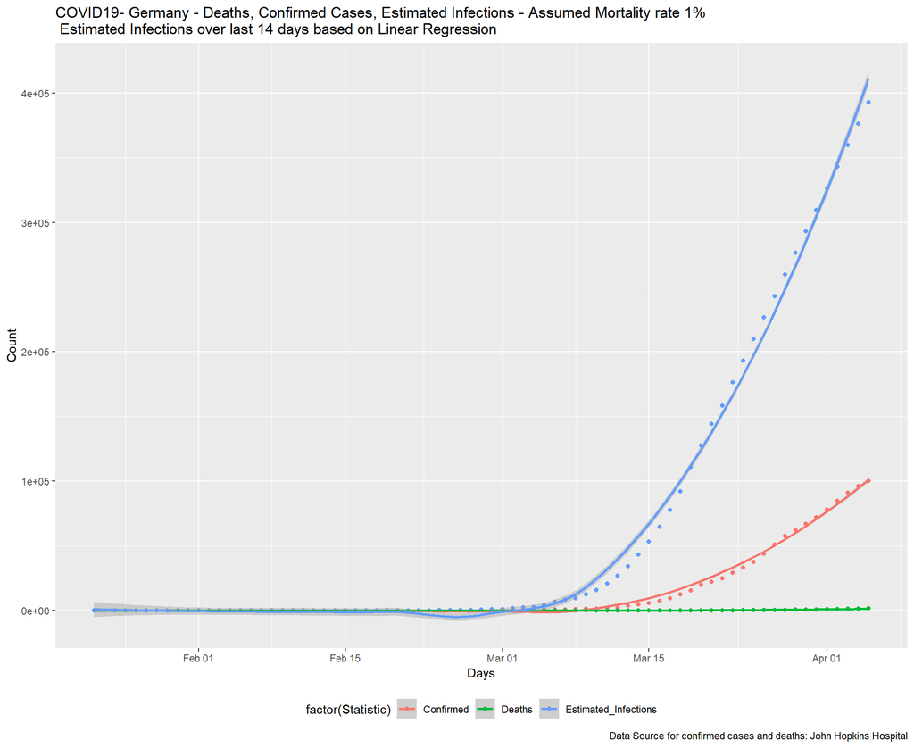

```r
Country.Long = Estimated.Infections.Country(Confirmed,Deaths,"Germany")
ggplot(Country.Long, aes(x= Date, y= Count, group=Statistic )) +   geom_point(aes(color = factor(Statistic))) + geom_smooth(method = "loess", aes(color = factor(Statistic))) + theme(legend.position="bottom") + labs(title="COVID19- Germany - Deaths, Confirmed Cases, Estimated Infections - Assumed Mortality rate 1% \n Estimated Infections over last 14 days based on Linear Regression", y="Count", x="Days", caption="Data Source for confirmed cases and deaths: John Hopkins Hospital")
```

The following code provides Trellis view of varying Mortality rates from 1% to 1.4% ; and the Lag from 10 to 14 days This will be done for Germany and South Korea which have large populations and have done extensive testing. The number of confirmed cases should track close to the Estimated Infections.

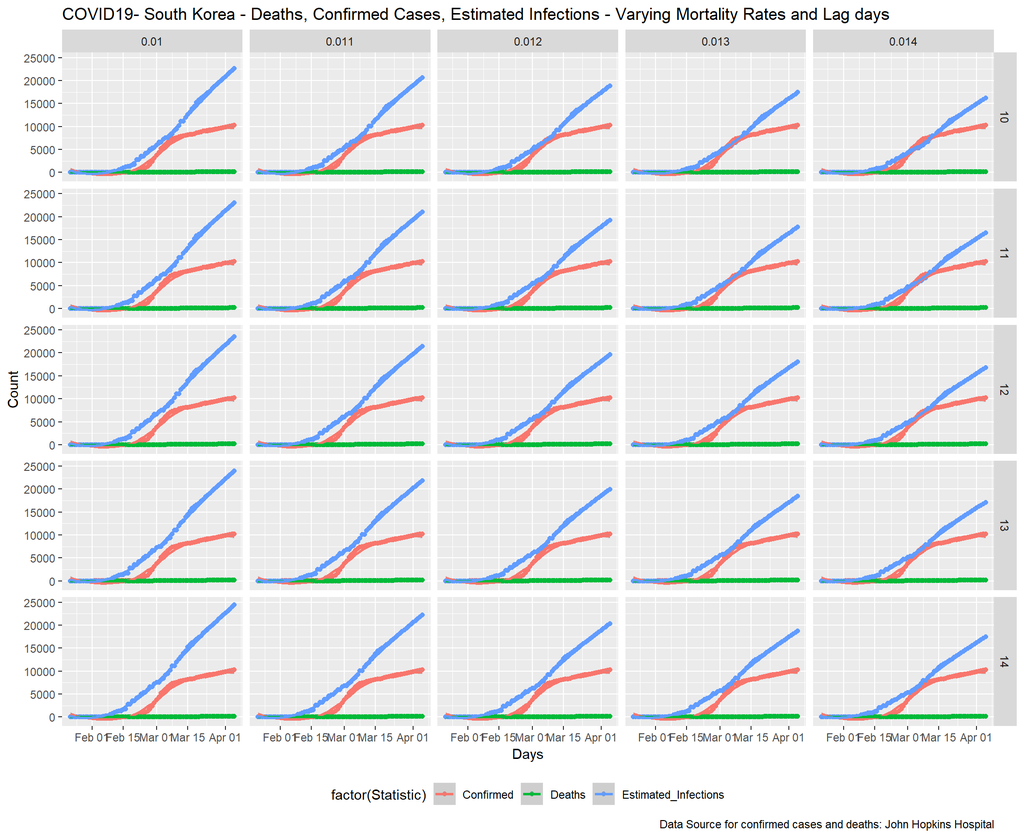

```r
# Charts for South, Korea

mortality = c(0.01, .011, .012, .013, .014)
lag = c(14,13, 12, 11, 10)
#Initialize with first case
Korea.Long = Estimated.Infections.Country(Confirmed,Deaths,"Korea, South",NA,lag[1],mortality[1])
Korea.Long$lag.value = lag[1]
Korea.Long$mortality.value = mortality[1]
#loop to populate the rest

for(i in 1:5){

  for (j in 1:5){
    #skip for step
    if (!(i==1 & j==1)) {temp = Estimated.Infections.Country(Confirmed,Deaths,"Korea, South",NA,lag[i],mortality[j])
    temp$lag.value = lag[i]
    temp$mortality.value = mortality[j]
    Korea.Long = rbind(Korea.Long,temp)}
  }
}

ggplot(Korea.Long, aes(x= Date, y= Count, group=Statistic )) +   geom_point(aes(color = factor(Statistic))) + geom_smooth(method = "loess", aes(color = factor(Statistic))) + theme(legend.position="bottom") + labs(title="COVID19- South Korea - Deaths, Confirmed Cases, Estimated Infections - Varying Mortality Rates and Lag days", y="Count", x="Days", caption="Data Source for confirmed cases and deaths: John Hopkins Hospital") + facet_grid(rows = vars(lag.value), cols = vars(mortality.value)) + facet_grid(vars(lag.value), vars(mortality.value))
```

For South Korea , It seems like Mortality Rates of 1.2% for Expected Infections seems high. We should use 1 or 1.1%. As for the Number of days 13 or 14 days of lag seem reasonable.

Now do the same for Germany

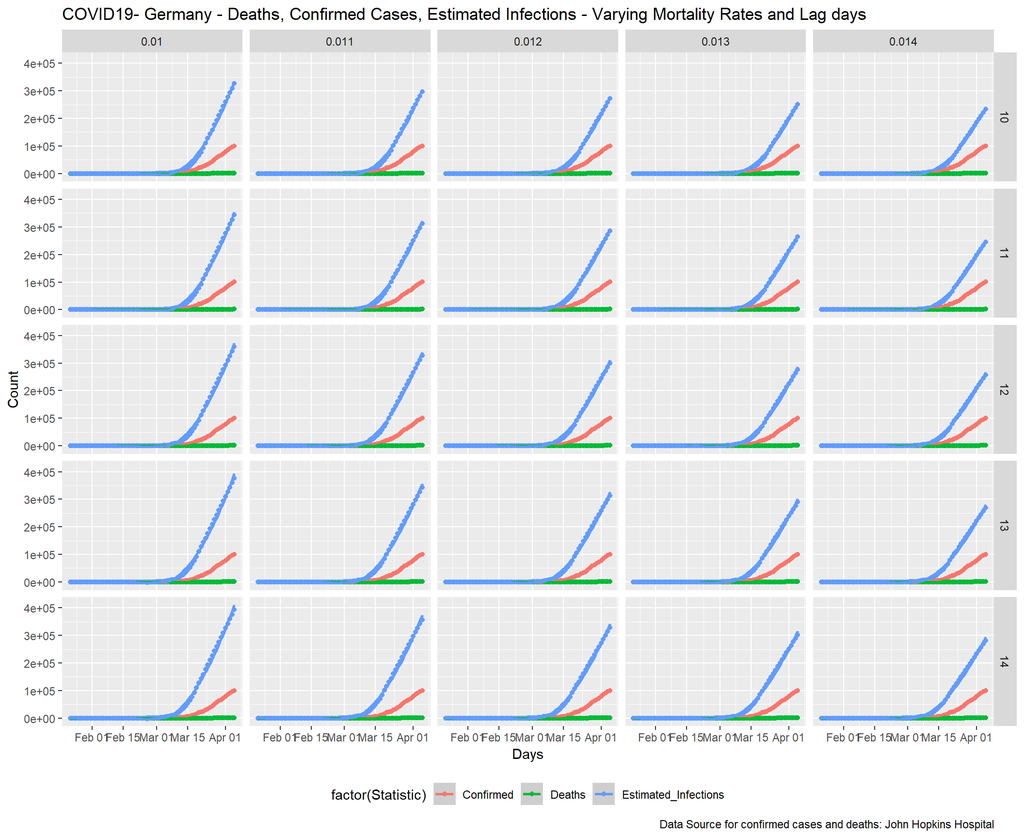

```r
# Charts for Germany

mortality = c(0.01, .011, .012, .013, .014)
lag = c(14,13, 12, 11, 10)
#Initialize with first case
Korea.Long = Estimated.Infections.Country(Confirmed,Deaths,"Germany",NA,lag[1],mortality[1])
Korea.Long$lag.value = lag[1]
Korea.Long$mortality.value = mortality[1]
#loop to populate the rest

for(i in 1:5){

  for (j in 1:5){
    #skip for step
    if (!(i==1 & j==1)) {temp = Estimated.Infections.Country(Confirmed,Deaths,"Germany",NA,lag[i],mortality[j])
    temp$lag.value = lag[i]
    temp$mortality.value = mortality[j]
    Korea.Long = rbind(Korea.Long,temp)}
  }
}

ggplot(Korea.Long, aes(x= Date, y= Count, group=Statistic )) +   geom_point(aes(color = factor(Statistic))) + geom_smooth(method = "loess", aes(color = factor(Statistic))) + theme(legend.position="bottom") + labs(title="COVID19- Germany - Deaths, Confirmed Cases, Estimated Infections - Varying Mortality Rates and Lag days", y="Count", x="Days", caption="Data Source for confirmed cases and deaths: John Hopkins Hospital") + facet_grid(rows = vars(lag.value), cols = vars(mortality.value)) + facet_grid(vars(lag.value), vars(mortality.value))
```

It seems like 1.1 of Mortality rate and 13 days for Germany. I will use in single charts to double check,

Try these two values for South Korea and Germany. Then show other locations in Europe and ASPAC. After that apply this to the US.

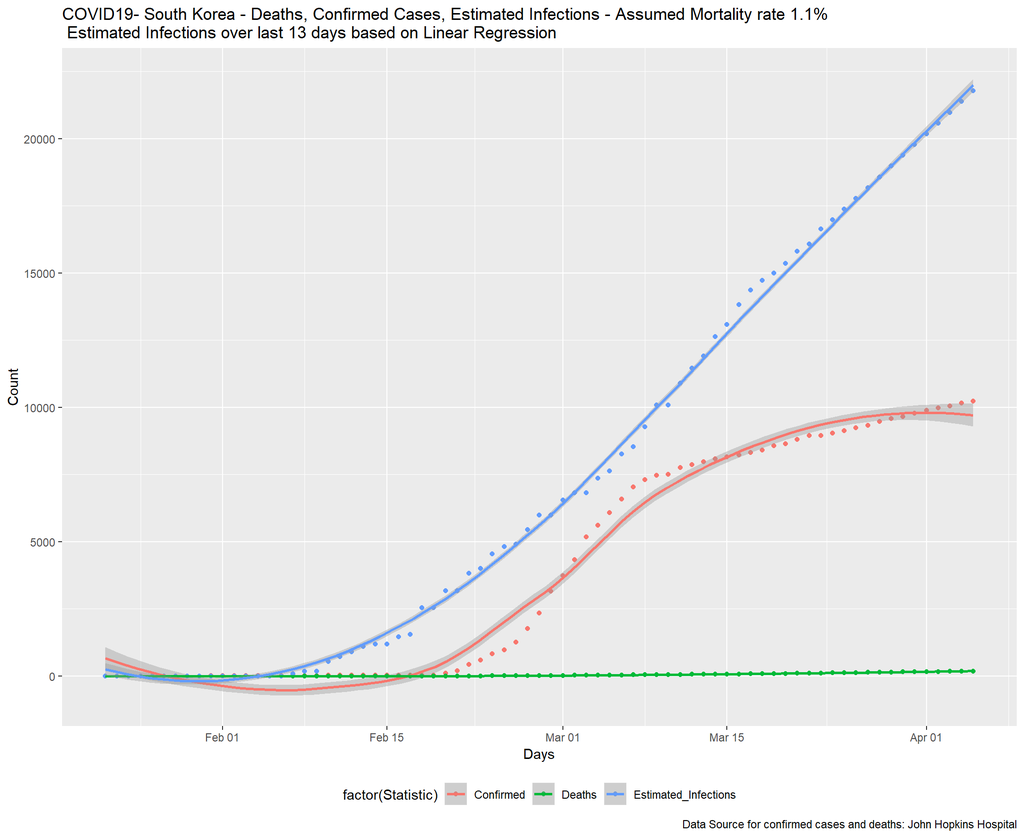

```r
#Example with South Korea and Germany - 1.1% Mortaliy rate and 13 day lag of Number of Death to Estimated Infections
Country.Long = Estimated.Infections.Country(Confirmed,Deaths,"Korea, South",NA,13,0.011)
ggplot(Country.Long, aes(x= Date, y= Count, group=Statistic )) +   geom_point(aes(color = factor(Statistic))) + geom_smooth(method = "loess", aes(color = factor(Statistic))) + theme(legend.position="bottom") + labs(title="COVID19- South Korea - Deaths, Confirmed Cases, Estimated Infections - Assumed Mortality rate 1.1% \n Estimated Infections over last 13 days based on Linear Regression", y="Count", x="Days", caption="Data Source for confirmed cases and deaths: John Hopkins Hospital")
```

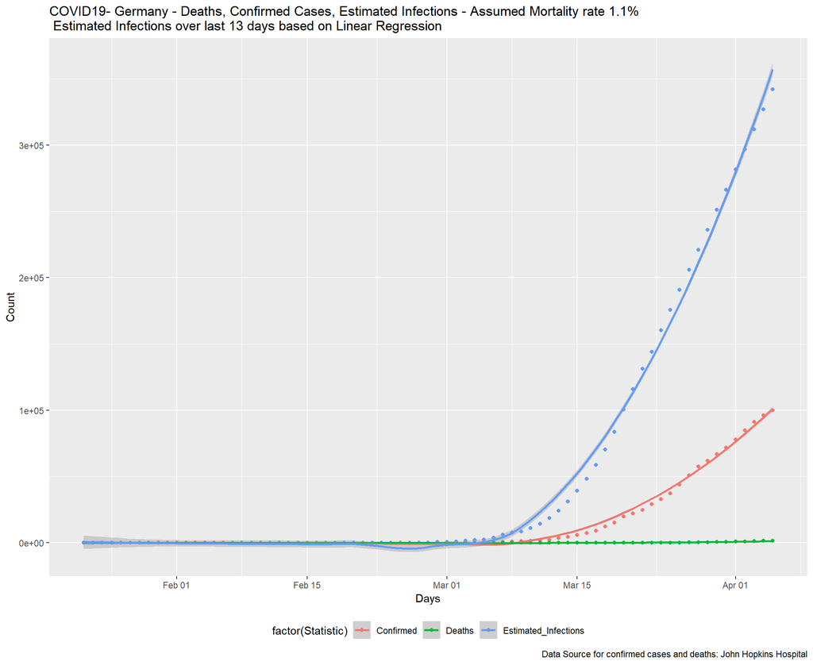

```r
Country.Long = Estimated.Infections.Country(Confirmed,Deaths,"Germany",NA,13,0.011)
ggplot(Country.Long, aes(x= Date, y= Count, group=Statistic )) +   geom_point(aes(color = factor(Statistic))) + geom_smooth(method = "loess", aes(color = factor(Statistic))) + theme(legend.position="bottom") + labs(title="COVID19- Germany - Deaths, Confirmed Cases, Estimated Infections - Assumed Mortality rate 1.1% \n Estimated Infections over last 13 days based on Linear Regression", y="Count", x="Days", caption="Data Source for confirmed cases and deaths: John Hopkins Hospital")
```

Check Singapore and Japan

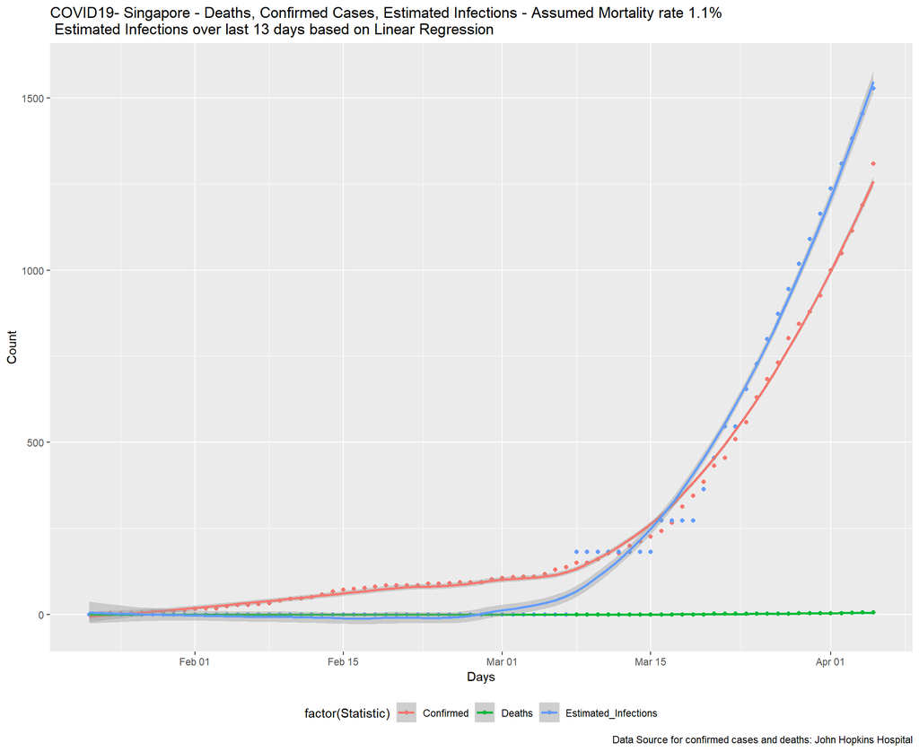

```r
#Example with Singapore and Japan - 1.1% Mortaliy rate and 13 day lag of Number of Death to Estimated Infections
Country.Long = Estimated.Infections.Country(Confirmed,Deaths,"Singapore",NA,13,0.011)
ggplot(Country.Long, aes(x= Date, y= Count, group=Statistic )) +   geom_point(aes(color = factor(Statistic))) + geom_smooth(method = "loess", aes(color = factor(Statistic))) + theme(legend.position="bottom") + labs(title="COVID19- Singapore - Deaths, Confirmed Cases, Estimated Infections - Assumed Mortality rate 1.1% \n Estimated Infections over last 13 days based on Linear Regression", y="Count", x="Days", caption="Data Source for confirmed cases and deaths: John Hopkins Hospital")
```

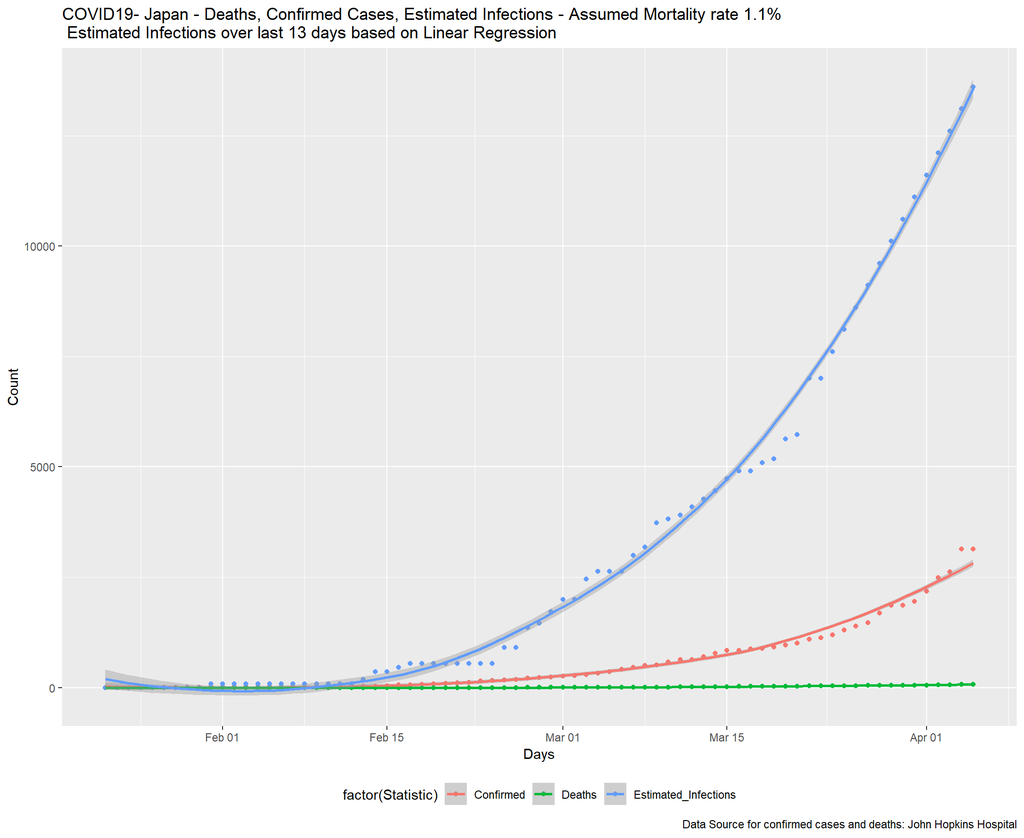

```r
Country.Long = Estimated.Infections.Country(Confirmed,Deaths,"Japan",NA,13,0.011)
ggplot(Country.Long, aes(x= Date, y= Count, group=Statistic )) +   geom_point(aes(color = factor(Statistic))) + geom_smooth(method = "loess", aes(color = factor(Statistic))) + theme(legend.position="bottom") + labs(title="COVID19- Japan - Deaths, Confirmed Cases, Estimated Infections - Assumed Mortality rate 1.1% \n Estimated Infections over last 13 days based on Linear Regression", y="Count", x="Days", caption="Data Source for confirmed cases and deaths: John Hopkins Hospital")
```

Check Italy and Spain

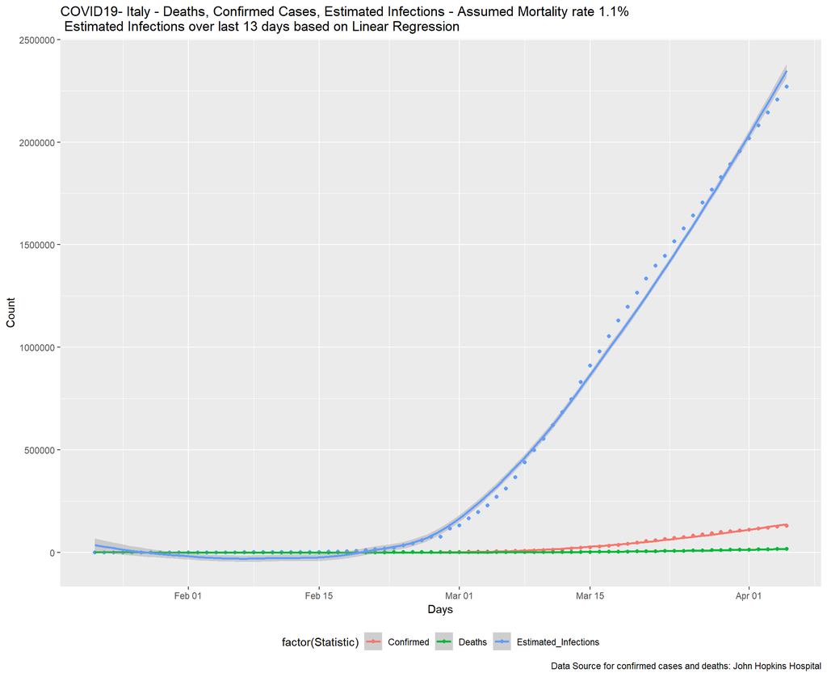

```r
#Example with Italy and Spain - 1.1% Mortaliy rate and 13 day lag of Number of Death to Estimated Infections
Country.Long = Estimated.Infections.Country(Confirmed,Deaths,"Italy",NA,13,0.011)
ggplot(Country.Long, aes(x= Date, y= Count, group=Statistic )) +   geom_point(aes(color = factor(Statistic))) + geom_smooth(method = "loess", aes(color = factor(Statistic))) + theme(legend.position="bottom") + labs(title="COVID19- Italy - Deaths, Confirmed Cases, Estimated Infections - Assumed Mortality rate 1.1% \n Estimated Infections over last 13 days based on Linear Regression", y="Count", x="Days", caption="Data Source for confirmed cases and deaths: John Hopkins Hospital")
```